# Graphiques sous R et Python dans Rstudio

Sebastien Foulle  
25/01/2019

### Contenu du document

On presente dans les slides suivantes les graphiques usuels en R avec *ggplot2* et *patchwork*, et en Python avec *seaborn*, *matplotlib* et *pandas*.

Ce document est une presentation Rstudio, cf https://support.rstudio.com/hc/en-us/sections/200130218-R-Presentations.

Ce format a moins de possibilites qu'un Rmarkdown (il faut par exemple exporter manuellement en html), mais il permet d'ecrire facilement sur deux colonnes.

Prerequis pour produire ce fichier html avec Rstudio a partir de la source “.Rpres” :

- une distribution Python (Anaconda convient tres bien)
- le package R *reticulate* qui permet d'utiliser des objets R dans des chunks Python (syntaxe *r.mon_objet_r*) et inversement (syntaxe *py$mon_objet_python*)

### Chargement des packages et donnees

```r
knitr:::opts_chunk$set(echo = TRUE, warning = FALSE, out.width= 1000, fig.asp=0.6, fig.align = 'center')


library("reticulate")
# chemin vers l'executable python
# Sys.which("Python")
use_python("C:/Users/Sebastien/Anaconda3/python.exe", required = FALSE)

library("dplyr")

library("ggplot2")
# pour centrer les titres des graphiques ggplot2
theme_update(plot.title = element_text(hjust = 0.5))

# pour la grille de graphiques
library("patchwork")

donnees = reshape2::tips %>% group_by(size, sex) %>% summarise(tip = mean(tip)) %>% ungroup
dir.create("images")
```

```python
import matplotlib.pyplot as plt
import seaborn as sns
sns.set()
```

### Solutions a des problemes techniques

Le format Rpres a un (petit) probleme avec les images des graphiques Python : dans le document html final les chemins vers les images dans les balises

[figure not shown]

sont des chemins complets, depuis la racine. Mais pour que le document html les trouve ces chemins devraient etre relatifs, a partir du dossier qui contient le html. On triche donc un peu dans chaque slide qui affiche un graphique :

1. On affiche le code qui devrait marcher mais on ne l'execute pas
2. On execute, mais sans l'afficher, le code et l'export de l'image en local
3. On recharge l'image locale dans le document sans afficher le code

Et pour eviter le message d'erreur *This application failed to start because it could not find or load the Qt platform plugin 'windows' in ''*, on a defini dans le script Rpres la variable d'environnement Python *QT_QPA_PLATFORM_PLUGIN_PATH* qui contient le chemin vers le sous-dossier 'plugins/platforms' du repertoire 'Anaconda', a vous d'adapter le chemin sur votre machine.

```python
import os
os.environ['QT_QPA_PLATFORM_PLUGIN_PATH'] = 'C:/Users/Sebastien/Anaconda3/Library/plugins/platforms'
os.chdir(".")
```

### Les donnees

```r
donnees
```

```
# A tibble: 12 x 3
    size sex      tip
   <int> <fct>  <dbl>
 1     1 Female  1.28
 2     1 Male    1.92
 3     2 Female  2.53
 4     2 Male    2.61
 5     3 Female  3.25
 6     3 Male    3.48
 7     4 Female  4.02
 8     4 Male    4.17
 9     5 Female  5.14
10     5 Male    3.75
11     6 Female  4.6
12     6 Male    5.85
```

```python
donnees = r.donnees; donnees
```

```
    size     sex       tip
0      1  Female  1.276667
1      1    Male  1.920000
2      2  Female  2.528448
3      2    Male  2.614184
4      3  Female  3.250000
5      3    Male  3.476667
6      4  Female  4.021111
7      4    Male  4.172143
8      5  Female  5.140000
9      5    Male  3.750000
10     6  Female  4.600000
11     6    Male  5.850000
```

```python
donnees_transposees = donnees.pivot(index='size', columns='sex', values='tip'); donnees_transposees
```

```
sex     Female      Male
size
1     1.276667  1.920000
2     2.528448  2.614184
3     3.250000  3.476667
4     4.021111  4.172143
5     5.140000  3.750000
6     4.600000  5.850000
```

### Courbes

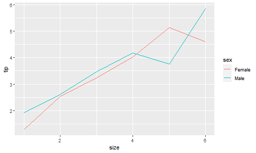

```r
ggplot(donnees, aes(size, tip, col = sex)) + geom_line()
```

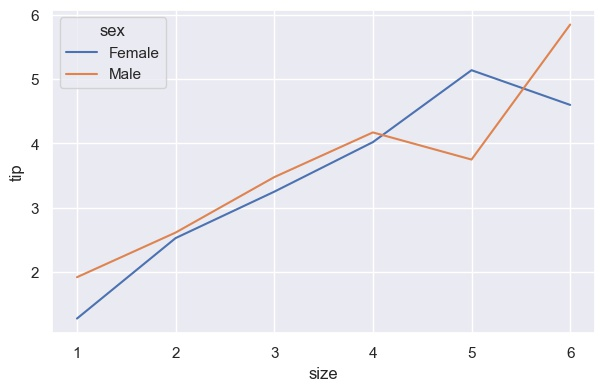

```python
sns.lineplot("size", "tip", hue="sex", data=donnees)
plt.show()
```

### Nuage de points

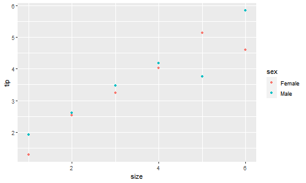

```r
ggplot(donnees, aes(size, tip, col = sex)) + geom_point()
```

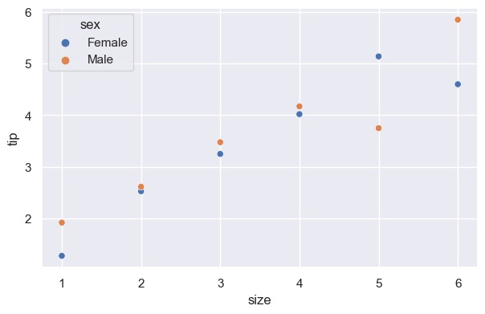

```python
sns.scatterplot("size", "tip", hue="sex", data=donnees)
# ou : sns.lmplot("size", "tip", hue="sex", data=donnees)
plt.show()
```

### Pavage hexagonal

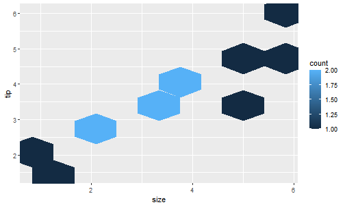

```r
ggplot(donnees, aes(size, tip)) + geom_hex(bins = 6)
```

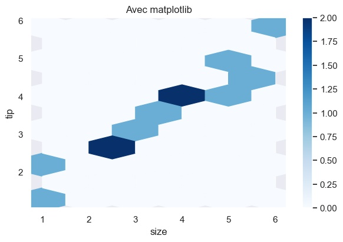

```python
plt.hexbin(donnees['size'], donnees['tip'], gridsize=(5,5), cmap="Blues")
plt.xlabel("size"); plt.ylabel("tip"); plt.title("Avec matplotlib"); plt.colorbar()
plt.show()
```

### Diagramme en barres groupees

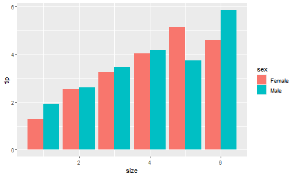

```r
ggplot(donnees, aes(size, tip, fill = sex)) + geom_col(position = "dodge")
```

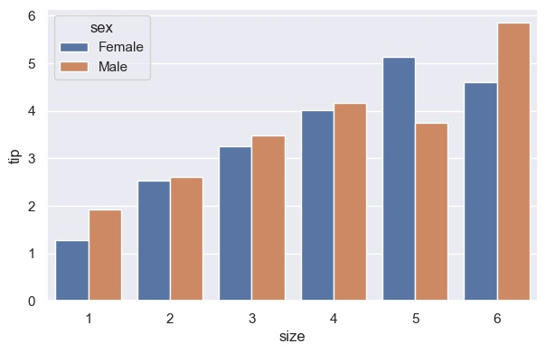

```python
sns.barplot("size", "tip", hue="sex", data=donnees)
plt.show()
```

### Diagramme en barres empilees

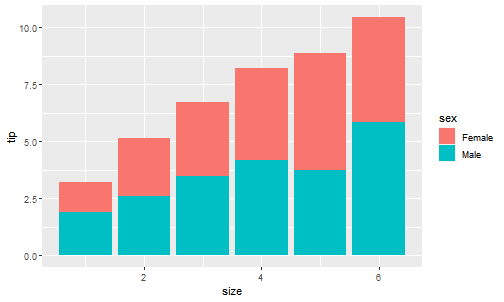

```r
ggplot(donnees, aes(size, tip, fill = sex)) + geom_col()
```

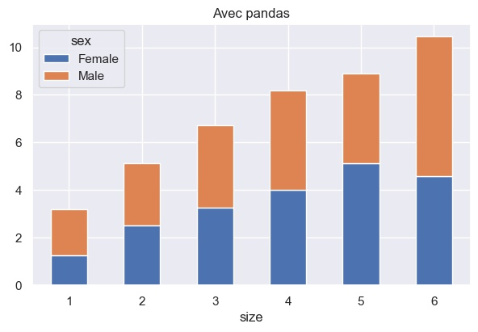

```python
donnees_transposees.plot.bar(stacked="True", rot = 0)
plt.title("Avec pandas")
plt.show()
```

### Histogramme

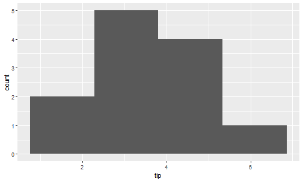

```r
ggplot(donnees, aes(tip)) + geom_histogram(bins = 4)
```

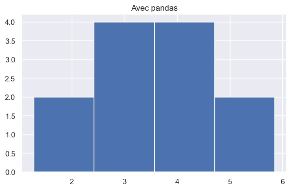

```python
donnees.tip.hist(bins = 4)
plt.title("Avec pandas")
# ou : sns.distplot(donnees.tip)
plt.show()
```

### Courbes de densite

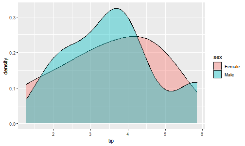

```r
ggplot(donnees, aes(tip, fill = sex)) + geom_density(alpha = 0.4)
```

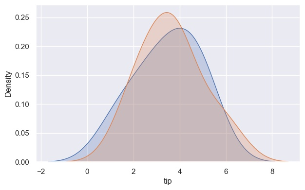

```python
for genre in donnees.sex.cat.categories:
    sns.kdeplot(donnees.tip[donnees.sex == genre], shade=True, label = genre)
plt.show()
```

### Boxplots

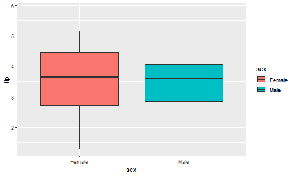

```r
ggplot(donnees, aes(sex, tip, fill = sex)) + geom_boxplot()
```

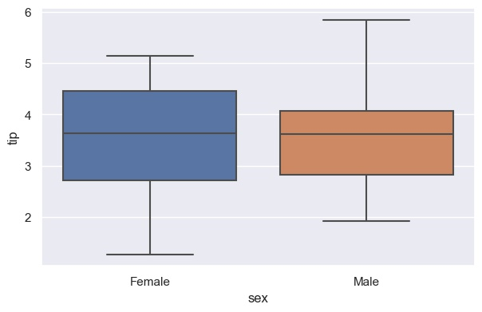

```python
sns.boxplot("sex", "tip", data=donnees)
plt.show()
```

### Faceting

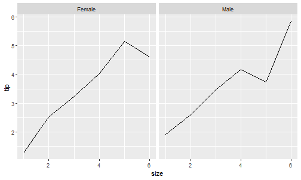

```r
ggplot(donnees, aes(size, tip)) + geom_line() + facet_grid(. ~ sex)
```

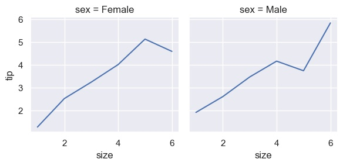

```python
g = sns.FacetGrid(donnees, col="sex").map(sns.lineplot, "size", "tip")
plt.show()
```

### Grille

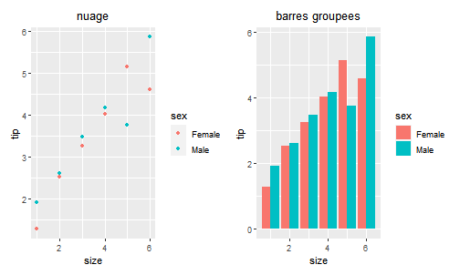

```r
ggplot(donnees, aes(size, tip, col = sex)) + geom_point() + ggtitle("nuage") |
  ggplot(donnees, aes(size, tip, fill = sex)) + geom_col(position = "dodge") + ggtitle("barres groupees")
```

[figure not shown]

```python
f, axes = plt.subplots(1, 2, figsize=(15, 10))
axes[0].set_title('nuage')
axes[1].set_title('barres groupees')
sns.barplot("size", "tip", hue="sex", data=donnees,  ax=axes[0])
sns.scatterplot("size", "tip", hue="sex", data=donnees,  ax=axes[1])
plt.show()
```